# Assignment 2: Rating Prediction on Amazon Beauty Reviews

**Team Members:** Bokyoung Son (Data Engineering), Hangyi Zhao (Baselines), Yujin Lee (Matrix Factorization), William Ayoade (Advanced Models)

**Dataset:** Amazon Reviews 2023 - All_Beauty Category

## Section 1: Task Definition

### Predictive Task

We aim to predict user ratings (1-5 stars) for beauty products on Amazon based on historical review data.

### Evaluation Metrics

- **MSE (Mean Squared Error):** Primary metric for rating prediction accuracy
- **RMSE (Root Mean Squared Error):** Interpretable version in original rating scale
- **MAE (Mean Absolute Error):** Average prediction error magnitude

### Baselines for Comparison

1. **Global Mean:** Predict average rating for all users/items
2. **User Mean:** Predict based on user's average rating
3. **Item Mean:** Predict based on item's average rating
4. **Bias Model:** Combines global mean with user/item biases

### Model Validation

- Train/test split: 80/20 with random seed 42
- Compare against baselines and prior work
- Analyze prediction errors and model behavior

## Section 2: Data Collection and Preprocessing

### Data Source

**Dataset:** Amazon Reviews 2023 - All_Beauty category  
**Source:** McAuley Lab (https://cseweb.ucsd.edu/~jmcauley/datasets.html)  
**Original size:** 701,528 reviews

### Preprocessing Steps

1. **Load raw data** from JSONL format
2. **K-core filtering** (min 2 reviews per user/item) to ensure data quality
3. **Train/test split** (80/20) with stratification
4. **Create user/item ID mappings** for matrix indexing

### Final Dataset Statistics

After preprocessing:

- **Total reviews:** 72,387
- **Train reviews:** 57,909 (80%)
- **Test reviews:** 14,478 (20%)
- **Unique users:** 29,162
- **Unique items:** 14,918
- **Sparsity:** 99.9%
- **Rating distribution:** Heavily skewed toward 5-star reviews (61.5%)

```python
# Setup and imports
import numpy as np
import pandas as pd
import pickle
from collections import defaultdict
from sklearn.metrics import mean_squared_error, mean_absolute_error
import matplotlib.pyplot as plt
import warnings
import re, ast
from PIL import Image
import requests
from io import BytesIO
warnings.filterwarnings('ignore')

print("Libraries imported successfully")
```

```
Libraries imported successfully
```

```python
"""
Data Preprocessing Pipeline
DSC256 Assignment 2
"""

import sys
sys.path.append('../src')

from data_loader import (
    download_amazon_reviews,
    load_reviews_from_parquet,
    preprocess_reviews,
    create_user_item_mappings,
    create_train_test_split,
    save_processed_data,
    get_dataset_statistics
)

import pandas as pd
import warnings
warnings.filterwarnings('ignore')

print("="*70)
print("Data prepocessing pipeline")
print("="*70)
```

```
======================================================================
Data prepocessing pipeline
======================================================================
```

```python
import pandas as pd
import json
import os
from tqdm import tqdm


# Path to manually downloaded file
jsonl_file = '/data/raw/All_Beauty.jsonl'

if not os.path.exists(jsonl_file):
    print(f"\n File not found: {jsonl_file}")
    print("\nPlease download the file manually:")
    print("1. Go to: https://huggingface.co/datasets/McAuley-Lab/Amazon-Reviews-2023/tree/main/raw/review_categories")
    print("2. Click on 'All_Beauty.jsonl'")
    print("3. Download it")
    print(f"4. Save it as: {jsonl_file}")
    raise FileNotFoundError(f"Please download the file to {jsonl_file}")

print(f"\n Loading data from: {jsonl_file}")
print(f"File size: {os.path.getsize(jsonl_file) / 1024 / 1024:.2f} MB")

# Configuration
USE_SAMPLE = True
MAX_REVIEWS = 700000

# Load JSONL file line by line
reviews = []

with open(jsonl_file, 'r', encoding='utf-8') as f:
    if USE_SAMPLE:
        print(f"  Sample mode: loading first {MAX_REVIEWS:,} reviews")
        pbar = tqdm(total=MAX_REVIEWS, desc="Loading reviews")

        for i, line in enumerate(f):
            if i >= MAX_REVIEWS:
                break
            try:
                review = json.loads(line)
                reviews.append(review)
                pbar.update(1)
            except json.JSONDecodeError as e:
                # print(e)
                continue

        pbar.close()
    else:
        print("Loading all reviews (this may take a while)...")
        for line in tqdm(f, desc="Loading reviews"):
            try:
                review = json.loads(line)
                reviews.append(review)
            except json.JSONDecodeError:
                continue

# Convert to DataFrame
df_raw = pd.DataFrame(reviews)

print(f"\n Loaded {len(df_raw):,} reviews")

# Save as standardized parquet file
raw_file = '../data/raw/All_Beauty_reviews.parquet'
df_raw.to_parquet(raw_file, index=False)

print(f" Saved to: {raw_file}")

print("\n" + "="*70)
print("DATA PREVIEW")
print("="*70)
print(df_raw.head())

print("\n" + "="*70)
print("COLUMN NAMES")
print("="*70)
print(df_raw.columns.tolist())

print("\n" + "="*70)
print("DATA TYPES")
print("="*70)
print(df_raw.dtypes)

print("\n" + "="*70)
print(" Data loaded successfully! Ready for preprocessing.")
print("="*70)
```

```
 Loading data from: /data/raw/All_Beauty.jsonl
File size: 471.96 MB
  Sample mode: loading first 700,000 reviews
```

```
 Loaded 700,000 reviews
 Saved to: ../data/raw/All_Beauty_reviews.parquet

======================================================================
DATA PREVIEW
======================================================================
   rating                                      title  \
0     5.0  Such a lovely scent but not overpowering.
1     4.0     Works great but smells a little weird.
2     5.0                                       Yes!
3     1.0                          Synthetic feeling
4     5.0                                         A+

                                                text images        asin  \
0  This spray is really nice. It smells really go...     []  B00YQ6X8EO
1  This product does what I need it to do, I just...     []  B081TJ8YS3
2                          Smells good, feels great!     []  B07PNNCSP9
3                                     Felt synthetic     []  B09JS339BZ
4                                            Love it     []  B08BZ63GMJ

  parent_asin                       user_id      timestamp  helpful_vote  \
0  B00YQ6X8EO  AGKHLEW2SOWHNMFQIJGBECAF7INQ  1588687728923             0
1  B081TJ8YS3  AGKHLEW2SOWHNMFQIJGBECAF7INQ  1588615855070             1
2  B097R46CSY  AE74DYR3QUGVPZJ3P7RFWBGIX7XQ  1589665266052             2
3  B09JS339BZ  AFQLNQNQYFWQZPJQZS6V3NZU4QBQ  1643393630220             0
4  B08BZ63GMJ  AFQLNQNQYFWQZPJQZS6V3NZU4QBQ  1609322563534             0

   verified_purchase
0               True
1               True
2               True
3               True
4               True

======================================================================
COLUMN NAMES
======================================================================
['rating', 'title', 'text', 'images', 'asin', 'parent_asin', 'user_id', 'timestamp', 'helpful_vote', 'verified_purchase']

======================================================================
DATA TYPES
======================================================================
rating               float64
title                 object
text                  object
images                object
asin                  object
parent_asin           object
user_id               object
timestamp              int64
helpful_vote           int64
verified_purchase       bool
dtype: object

======================================================================
 Data loaded successfully! Ready for preprocessing.
======================================================================
```

```python
df_raw = load_reviews_from_parquet(raw_file)

# Show first few rows
df_raw.head()
```

```
Loading reviews from: ../data/raw/All_Beauty_reviews.parquet
Loaded 700,000 reviews
```

|  | rating | title | text | images | asin | parent_asin | user_id | timestamp | helpful_vote | verified_purchase |
| --- | --- | --- | --- | --- | --- | --- | --- | --- | --- | --- |
| 0 | 5.0 | Such a lovely scent but not overpowering. | This spray is really nice. It smells really go... | [] | B00YQ6X8EO | B00YQ6X8EO | AGKHLEW2SOWHNMFQIJGBECAF7INQ | 1588687728923 | 0 | True |
| 1 | 4.0 | Works great but smells a little weird. | This product does what I need it to do, I just... | [] | B081TJ8YS3 | B081TJ8YS3 | AGKHLEW2SOWHNMFQIJGBECAF7INQ | 1588615855070 | 1 | True |
| 2 | 5.0 | Yes! | Smells good, feels great! | [] | B07PNNCSP9 | B097R46CSY | AE74DYR3QUGVPZJ3P7RFWBGIX7XQ | 1589665266052 | 2 | True |
| 3 | 1.0 | Synthetic feeling | Felt synthetic | [] | B09JS339BZ | B09JS339BZ | AFQLNQNQYFWQZPJQZS6V3NZU4QBQ | 1643393630220 | 0 | True |
| 4 | 5.0 | A+ | Love it | [] | B08BZ63GMJ | B08BZ63GMJ | AFQLNQNQYFWQZPJQZS6V3NZU4QBQ | 1609322563534 | 0 | True |

```python
df_clean = preprocess_reviews(
    df_raw,
    min_user_reviews=2,
    min_item_reviews=2
)
```

```
============================================================
Processing data
============================================================

Original dataset: 700,000 reviews
After removing invalid ratings (0 or >5): 700,000 reviews (100.0%)

Applying k-core filtering (min_user=2, min_item=2)...
  Iteration 1: 108,154 reviews (removed 591,846)
  Iteration 2: 86,985 reviews (removed 21,169)
  Iteration 3: 76,916 reviews (removed 10,069)
  Iteration 4: 74,601 reviews (removed 2,315)
  Iteration 5: 73,157 reviews (removed 1,444)
  Iteration 6: 72,783 reviews (removed 374)
  Iteration 7: 72,537 reviews (removed 246)
  Iteration 8: 72,465 reviews (removed 72)
  Iteration 9: 72,418 reviews (removed 47)
  Iteration 10: 72,402 reviews (removed 16)
  Iteration 11: 72,393 reviews (removed 9)
  Iteration 12: 72,390 reviews (removed 3)
  Iteration 13: 72,388 reviews (removed 2)
  Iteration 14: 72,387 reviews (removed 1)
  Iteration 15: 72,387 reviews (removed 0)

After k-core: 72,387 reviews (10.3% retained)
Unique users: 29,162
Unique items: 14,918
```

```python
# we map all users and items to a numeric index
user_to_idx, item_to_idx = create_user_item_mappings(df_clean)
```

```
============================================================
CREATING ID MAPPINGS
============================================================

Created mappings:
  Users: 29,162
  Items: 14,918
```

```python
# creates reproducible 80/20 training/testing split
train_df, test_df = create_train_test_split(
    df_clean,
    test_size=0.2,
    random_state=42
)
```

```
============================================================
CREATING TRAIN/TEST SPLIT
============================================================

Split: 80% train / 20% test
  Train: 57,909 reviews
  Test:  14,478 reviews
```

```python
# Save all processed data
save_processed_data(
    train_df,
    test_df,
    user_to_idx,
    item_to_idx,
    output_dir='/data/processed'
)
```

```
============================================================
SAVING PROCESSED DATA
============================================================

Saving to: /data/processed
Saved files:
  - train.csv & train.parquet
  - test.csv & test.parquet
  - user_to_idx.pkl (29,162 users)
  - item_to_idx.pkl (14,918 items)
  - metadata.pkl
```

```python
# Generate comprehensive statistics
stats = get_dataset_statistics(train_df, test_df, user_to_idx, item_to_idx)

print("\n" + "="*70)
print("DATASET STATISTICS SUMMARY")
print("="*70)

print(f"\n Dataset Overview:")
print(f"  Total reviews: {stats['n_reviews_total']:,}")
print(f"  Train reviews: {stats['n_reviews_train']:,}")
print(f"  Test reviews:  {stats['n_reviews_test']:,}")
print(f"  Unique users:  {stats['n_users']:,}")
print(f"  Unique items:  {stats['n_items']:,}")

print(f"\n Sparsity:")
print(f"  Density:  {stats['density']*100:.6f}%")
print(f"  Sparsity: {stats['sparsity']*100:.4f}%")

print(f"\n Rating Statistics:")
print(f"  Mean: {stats['rating_mean']:.3f}")
print(f"  Std:  {stats['rating_std']:.3f}")
print(f"  Range: [{stats['rating_min']:.1f}, {stats['rating_max']:.1f}]")

print(f"\n User Activity:")
print(f"  Mean reviews per user:   {stats['reviews_per_user_mean']:.2f}")
print(f"  Median reviews per user: {stats['reviews_per_user_median']:.0f}")
print(f"  Max reviews by one user: {stats['reviews_per_user_max']:,}")

print(f"\n Item Popularity:")
print(f"  Mean reviews per item:   {stats['reviews_per_item_mean']:.2f}")
print(f"  Median reviews per item: {stats['reviews_per_item_median']:.0f}")
print(f"  Max reviews for one item: {stats['reviews_per_item_max']:,}")

print(f"\n Rating Distribution:")
for rating, count in sorted(stats['rating_distribution'].items()):
    pct = count / stats['n_reviews_total'] * 100
    print(f"  {rating} stars: {count:,} ({pct:.1f}%)")

print("\n" + "="*70)
print("✅ PREPROCESSING COMPLETE!")
print("="*70)
print("from src.data_loader import load_splits")
print("train, test, user_map, item_map = load_splits()")
```

```
======================================================================
DATASET STATISTICS SUMMARY
======================================================================

 Dataset Overview:
  Total reviews: 72,387
  Train reviews: 57,909
  Test reviews:  14,478
  Unique users:  29,162
  Unique items:  14,918

 Sparsity:
  Density:  0.016639%
  Sparsity: 99.9834%

 Rating Statistics:
  Mean: 4.124
  Std:  1.337
  Range: [1.0, 5.0]

 User Activity:
  Mean reviews per user:   2.48
  Median reviews per user: 2
  Max reviews by one user: 146

 Item Popularity:
  Mean reviews per item:   4.85
  Median reviews per item: 3
  Max reviews for one item: 202

 Rating Distribution:
  1.0 stars: 7,138 (9.9%)
  2.0 stars: 3,851 (5.3%)
  3.0 stars: 6,394 (8.8%)
  4.0 stars: 10,502 (14.5%)
  5.0 stars: 44,502 (61.5%)

======================================================================
✅ PREPROCESSING COMPLETE!
======================================================================
from src.data_loader import load_splits
train, test, user_map, item_map = load_splits()
```

```python
# Verify files were created
import os

processed_dir = '../data/processed'

files_to_check = [
    'train.csv',
    'train.parquet',
    'test.csv',
    'test.parquet',
    'user_to_idx.pkl',
    'item_to_idx.pkl',
    'metadata.pkl'
]

all_good = True
for filename in files_to_check:
    filepath = os.path.join(processed_dir, filename)
    if os.path.exists(filepath):
        size_mb = os.path.getsize(filepath) / 1024 / 1024
        print(f" {filename:20s} ({size_mb:6.2f} MB)")
    else:
        print(f" {filename:20s} MISSING!")
        all_good = False

if all_good:
    print("\n All files created successfully!")
    print("\n Files location: C:\\Users\\momo9\\Desktop\\DSC256R_Assignment2\\data\\processed")
else:
    print("\n Some files are missing!")
```

```
 train.csv            ( 25.10 MB)
 train.parquet        ( 12.59 MB)
 test.csv             (  6.26 MB)
 test.parquet         (  3.38 MB)
 user_to_idx.pkl      (  0.95 MB)
 item_to_idx.pkl      (  0.23 MB)
 metadata.pkl         (  0.00 MB)

 All files created successfully!

 Files location: C:\Users\momo9\Desktop\DSC256R_Assignment2\data\processed
```

```python
# Check for 0 or missing ratings
print("Investigating rating values...")
print("="*70)

print("\nRating value counts (including 0):")
print(df_raw['rating'].value_counts(dropna=False).sort_index())

print("\nNumber of 0 ratings:", (df_raw['rating'] == 0).sum())
print("Number of NaN ratings:", df_raw['rating'].isna().sum())

print("\nSample of reviews with rating = 0:")
zero_ratings = df_raw[df_raw['rating'] == 0]
if len(zero_ratings) > 0:
    print(zero_ratings[['rating', 'user_id', 'parent_asin', 'text']].head())
else:
    print("No 0 ratings found")

print("\n" + "="*70)
```

```
Investigating rating values...
======================================================================

Rating value counts (including 0):
rating
1.0    101719
2.0     42944
3.0     56214
4.0     79244
5.0    419879
Name: count, dtype: int64

Number of 0 ratings: 0
Number of NaN ratings: 0

Sample of reviews with rating = 0:
No 0 ratings found

======================================================================
```

### Now we can process the image and textual data

```python
# IMAGE PROCESSING(slow)
'''
Image data
We processes the "images" column, which contains string-encoded lists of image
metadata. First we clean and parse these strings to extract usable urls, which
we then download, pixelize and encode as vectors which can be used by our model.
'''


df = pd.read_csv("/data/processed/train.csv")
print(f"Loaded train.csv: {df.shape}")


IMG_SIZE = (32, 32)           # 32x32 pixel encoding (low for speed, can be increased)
TIMEOUT = 5                   # 5 second timeout per HTTP request
SAVE_IMAGES = False           # keeps raw downloaded images if needed

# helper functions for processing the image data
def parse_images_field(raw):
    """
    Images are stored as strings, we convert these strings into usable dictionaries
    """
    if not isinstance(raw, str):
        return []

    raw = raw.strip()
    if raw == "" or raw == "[]" or raw.lower() == "nan":
        return []

    # Remove wrapping
    if raw.startswith("'[") and raw.endswith("]'"):
        raw = raw[1:-1]

    # Insert commas between dicts:  } {  ->  }, {
    raw_fixed = re.sub(r"}\s*{", "}, {", raw)

    try:
        parsed = ast.literal_eval(raw_fixed)
        return parsed if isinstance(parsed, list) else []
    except Exception as e:
        # debugging for bad entries
        print("\n--- PARSE ERROR ---")
        print("RAW:", raw[:200])
        print("FIXED:", raw_fixed[:200])
        print("ERROR:", e)
        return []

def extract_first_url(images_list):
  """
  We have list of urls, extract best one.
  Order: large -> medium -> small
  """
  for obj in images_list:
      if not isinstance(obj, dict):
          continue
      url = obj.get("large_image_url") or obj.get("medium_image_url") or obj.get("small_image_url")
      if url is not None:
          return url
  return None

def download_and_vectorize(url):
  """
  Try and fetch image. Then pixelate, and flatten image as usable vector
  """
  try:
      resp = requests.get(url, timeout=TIMEOUT)
      img = Image.open(BytesIO(resp.content)).convert("RGB")
      img = img.resize(IMG_SIZE)
      vec = np.asarray(img).flatten() / 255.0
      return vec
  except Exception:
      return None
```

```
Loaded train.csv: (57909, 10)
```

```python
item_to_vec = {}
success = 0
fail_parse = 0
fail_download = 0
rows_with_images = 0

print("\n=== BEGIN FULL IMAGE PREPROCESSING ===")
for idx, row in tqdm(df.iterrows(), total=len(df)):

    item = row["item_id"]
    raw = row["images"]

    parsed = parse_images_field(raw)
    if len(parsed) == 0:
        continue

    rows_with_images += 1
    url = extract_first_url(parsed)
    if url is None:
        fail_parse += 1
        continue

    # avoid re-downloading for same item
    if item in item_to_vec:
        continue

    vec = download_and_vectorize(url)
    if vec is None:
        fail_download += 1
        continue

    item_to_vec[item] = vec
    success += 1
```

```
=== BEGIN FULL IMAGE PREPROCESSING ===
```

```python
print("\n=== IMAGE PROCESSING SUMMARY ===")
print(f"Rows with any image data:     {rows_with_images}")
print(f"Valid images successfully downloaded: {success}")
print(f"Failed parses (URLs missing): {fail_parse}")
print(f"Failed downloads:             {fail_download}")
print(f"Final vector dictionary size: {len(item_to_vec)}")

# Turn into matrix form if you want PCA or direct ML usage
item_ids = list(item_to_vec.keys())
image_matrix = np.vstack([item_to_vec[i] for i in item_ids])

print("\nFinal image_matrix shape:", image_matrix.shape)
```

```
=== IMAGE PROCESSING SUMMARY ===
Rows with any image data:     7749
Valid images successfully downloaded: 4219
Failed parses (URLs missing): 0
Failed downloads:             29
Final vector dictionary size: 4219

Final image_matrix shape: (4219, 3072)
```

```python
#   - item_ids:     list of item_id strings (ASIN codes)
#   - image_matrix: list/array of flattened pixel vectors
#   - item_to_vec:  dict { item_id_string : vector }

print("Example item_ids element:", item_ids[0])



image_matrix_np = np.asarray(image_matrix, dtype=np.float32)
item_ids_array = np.asarray(item_ids, dtype=object)

print("image_matrix_np shape:", image_matrix_np.shape)
print("item_ids_array shape:", item_ids_array.shape)

assert len(image_matrix_np) == len(item_ids_array)

if "item_to_vec" not in globals():
    item_to_vec = {
        item_id: vec for item_id, vec in zip(item_ids_array, image_matrix_np)
    }
    print("Reconstructed item_to_vec dict.")
else:
    print("item_to_vec already exists (size =", len(item_to_vec), ")")


save_dir = "/data/processed/images"
os.makedirs(save_dir, exist_ok=True)


np.save(os.path.join(save_dir, "image_item_ids.npy"), item_ids_array)
np.save(os.path.join(save_dir, "image_vectors.npy"), image_matrix_np)
with open(os.path.join(save_dir, "image_vectors.pkl"), "wb") as f:
    pickle.dump(item_to_vec, f)


with open(os.path.join(save_dir, "image_metadata.txt"), "w") as f:
    f.write("IMAGE PREPROCESSING OUTPUT\n")
    f.write("==========================\n")
    f.write(f"Total unique items with images: {len(item_ids_array)}\n")
    f.write(f"Image vector dimension: {image_matrix_np.shape[1]}\n")
    f.write(f"Saved in: {save_dir}\n")

print("\n=== IMAGE EMBEDDINGS SAVED SUCCESSFULLY ===")
print(f"Directory: {save_dir}")
print(f"- image_item_ids.npy  (dtype: object, strings OK)")
print(f"- image_vectors.npy")
print(f"- image_vectors.pkl")
print(f"- image_metadata.txt")
```

```
Example item_ids element: B088NQ6T9N
image_matrix_np shape: (4219, 3072)
item_ids_array shape: (4219,)
item_to_vec already exists (size = 4219 )

=== IMAGE EMBEDDINGS SAVED SUCCESSFULLY ===
Directory: /data/processed/images
- image_item_ids.npy  (dtype: object, strings OK)
- image_vectors.npy
- image_vectors.pkl
- image_metadata.txt
```

```
Item ID: B08C76WXH4

								Step 1
======================================================================
```

[figure not shown]

```
								Step 2
======================================================================
```

[figure not shown]

```
								Step 3
======================================================================
```

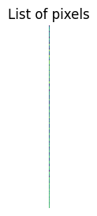

```
								Step 4
======================================================================
Vector of floats [[0.03921569]
 [0.03529412]
 [0.04313725]
 ...
 [0.78039216]
 [0.72156863]
 [0.6       ]]
```

```python
# Example of image encoding

with open("/data/processed/images/image_vectors.pkl", "rb") as f:
    item_to_vec = pickle.load(f)
sample_item = list(item_to_vec.keys())[1]
print(f"Item ID: {sample_item}")
sample_item_url = "https://images-na.ssl-images-amazon.com/images/I/81ASLCJJhpL._SL1600_.jpg"

try:
    # Download image
    response = requests.get(sample_item_url, timeout=10)
    response.raise_for_status()

    # Load with PIL
    img = Image.open(BytesIO(response.content))
    print("\n\t\t\t\t\t\t\t\tStep 1")
    print("="*70)
    # Display
    plt.figure(figsize=(3,3))
    plt.imshow(img)
    plt.axis("off")
    plt.title("Original Image")
    plt.show()


except Exception as e:
    print("Error:", e)

# Pick one item with an image

vec = item_to_vec[sample_item]
vec = vec.reshape(-1, 1)
# Reshape 32x32x3
img2 = vec.reshape(32, 32, 3)
print("\n\t\t\t\t\t\t\t\tStep 2")
print("="*70)
plt.figure(figsize=(3,3))
plt.imshow(img2)
plt.title("Pixelized Image")
plt.axis("off")
plt.show()


vec = vec.reshape(-1, 1)
print("\n\t\t\t\t\t\t\t\tStep 3")
print("="*70)
plt.figure(figsize=(3,3))
plt.imshow(vec)
plt.title("List of pixels")
plt.axis("off")
plt.show()

print("\n\t\t\t\t\t\t\t\tStep 4")
print("="*70)
print("Vector of floats",vec)
```

```python
# text processing
from sklearn.feature_extraction.text import TfidfVectorizer
from sklearn.decomposition import TruncatedSVD
# Load preprocessed data
train = pd.read_csv('/data/processed/train.csv')
test = pd.read_csv('/data/processed/test.csv')



def clean_text(text):
    if not isinstance(text, str):
        return ""
    text = text.lower()

    # remove HTML
    text = re.sub(r"<.*?>", " ", text)

    # remove URLs
    text = re.sub(r"http\S+", " ", text)

    return re.sub(r"\s+", " ", text).strip()
train["clean_text"] = train["text"].apply(clean_text)
test["clean_text"]  = test["text"].apply(clean_text)


'''
  We define a list of stopwords to ignore, as they are common and dont
  provide useful information to our model
'''
stopwords = [
    "the","a","an","and","or","but","if","then","when","while","so", "i","me",
    "my","we","us","our","you","your","he","she","it","they","them","their",
    "is","am","are","was","were","be","been","being", "do","does","did","doing",
    "have","has","had","having", "for","to","from","in","on","at","by","of",
    "with","as","about","into", "over","under","through", "item"
]






# We create unigram, bigram, and trigrams from the review text
tfidf = TfidfVectorizer(
    stop_words=stopwords,
    ngram_range=(1,3),
    max_features=25000,
    min_df=3
)

tfidf_matrix = tfidf.fit_transform(train["clean_text"])
print("TF-IDF shape:", tfidf_matrix.shape)



# we shrink our dimentionality to 128,
# which improves speed while still keeping meaning
svd_dim = 128
svd = TruncatedSVD(n_components=svd_dim)

train_text_embeds = svd.fit_transform(tfidf_matrix)



# We create a text vector embedding for each item, stored as an item:vector dict
item_text_vecs = {}
grouped = train.groupby("item_id")

for item_id, grp in tqdm(grouped, desc="Building per-item text vectors"):
    idxs = grp.index
    # average all review vectors for this item
    item_text_vecs[item_id] = train_text_embeds[idxs].mean(axis=0)



save_dir = "/data/processed/text_vectors"
os.makedirs(save_dir, exist_ok=True)

with open(f"{save_dir}/item_text_vecs.pkl", "wb") as f:
    pickle.dump(item_text_vecs, f)

with open(f"{save_dir}/tfidf_model.pkl", "wb") as f:
    pickle.dump(tfidf, f)

with open(f"{save_dir}/svd_model.pkl", "wb") as f:
    pickle.dump(svd, f)

print("\n=== TEXT VECTORS SAVED SUCCESSFULLY ===")
print("Directory:", save_dir)




def load_text_vectors():
    with open("/data/processed/text_vectors/item_text_vecs.pkl", "rb") as f:
        return pickle.load(f)

def load_text_models():
    with open("/data/processed/text_vectors/tfidf_model.pkl", "rb") as f:
        tfidf = pickle.load(f)
    with open("/data/processed/text_vectors/svd_model.pkl", "rb") as f:
        svd = pickle.load(f)
    return tfidf, svd





def get_text_vector(item_id, item_text_vecs):
    """
    Returns the 128-dim vector for item_id.
    If the item has no text reviews, returns zero vector.
    """
    return item_text_vecs.get(item_id, np.zeros(svd_dim))
```

```
TF-IDF shape: (57909, 25000)
```

```
=== TEXT VECTORS SAVED SUCCESSFULLY ===
Directory: /data/processed/text_vectors
```

### Exploratory Data Analysis

Key observations:

- **High sparsity (99.9%):** Most user-item pairs have no interactions
- **Rating skew:** 61.5% of ratings are 5 stars, indicating positive bias
- **Cold start:** Many users and items have very few reviews (median = 2)
- **Imbalanced distribution:** This makes predicting low ratings challenging

# Section 3: Modeling

## Baseline Models (Person 2):

### Model Architectures

We implement four baseline models:

1. **Global Mean Baseline**
   - Prediction: $\hat{r} = \mu$ (global average)
   - Simplest baseline, ignores user/item differences
2. **User Mean Baseline**
   - Prediction: $\hat{r}_{ui} = \frac{1}{|I_u|} \sum_{j \in I_u} r_{uj}$
   - Uses only user's average rating
3. **Item Mean Baseline**
   - Prediction: $\hat{r}_{ui} = \frac{1}{|U_i|} \sum_{v \in U_i} r_{vi}$
   - Uses only item's average rating
4. **Bias Model** (Best baseline)
   - Prediction: $\hat{r}_{ui} = \mu + \beta_u + \beta_i$
   - Combines global mean with user and item biases
   - Trained via coordinate descent with L2 regularization ($\lambda = 5$)

### Implementation Details

```python
# Load preprocessed data
train = pd.read_csv('/data/processed/train.csv')
test = pd.read_csv('/data/processed/test.csv')

with open("/data/processed/user_to_idx.pkl", "rb") as f:
    user_to_idx = pickle.load(f)
with open("/data/processed/item_to_idx.pkl", "rb") as f:
    item_to_idx = pickle.load(f)

print(f"Train reviews: {len(train):,}")
print(f"Test reviews:  {len(test):,}")
print(f"Unique users:  {len(user_to_idx):,}")
print(f"Unique items:  {len(item_to_idx):,}")
print(f"\nRating distribution:")
print(train['rating'].value_counts().sort_index())
```

```
Train reviews: 57,909
Test reviews:  14,478
Unique users:  29,162
Unique items:  14,918

Rating distribution:
rating
1.0     5701
2.0     3088
3.0     5052
4.0     8362
5.0    35706
Name: count, dtype: int64
```

```python
# Baseline 1: Global Mean
global_mean = train['rating'].mean()
global_mean_preds = [global_mean] * len(test)
global_mean_mse = mean_squared_error(test['rating'], global_mean_preds)

print(f"Global Mean Baseline")
print(f"  Mean: {global_mean:.3f}")
print(f"  Test MSE: {global_mean_mse:.4f}")
print(f"  Test RMSE: {np.sqrt(global_mean_mse):.4f}\n")
```

```
Global Mean Baseline
  Mean: 4.127
  Test MSE: 1.7921
  Test RMSE: 1.3387
```

```python
# Baseline 2: User Mean
user_means = train.groupby('user_id')['rating'].mean().to_dict()
user_mean_preds = [user_means.get(row['user_id'], global_mean) for _, row in test.iterrows()]
user_mean_mse = mean_squared_error(test['rating'], user_mean_preds)

print(f"User Mean Baseline")
print(f"  Test MSE: {user_mean_mse:.4f}")
print(f"  Test RMSE: {np.sqrt(user_mean_mse):.4f}\n")
```

```
User Mean Baseline
  Test MSE: 1.9058
  Test RMSE: 1.3805
```

```python
# Baseline 3: Item Mean
item_means = train.groupby('item_id')['rating'].mean().to_dict()
item_mean_preds = [item_means.get(row['item_id'], global_mean) for _, row in test.iterrows()]
item_mean_mse = mean_squared_error(test['rating'], item_mean_preds)

print(f"Item Mean Baseline")
print(f"  Test MSE: {item_mean_mse:.4f}")
print(f"  Test RMSE: {np.sqrt(item_mean_mse):.4f}\n")
```

```
Item Mean Baseline
  Test MSE: 1.8532
  Test RMSE: 1.3613
```

```python
# Baseline 4: Bias Model
# Prepare data structures
ratingsPerUser = defaultdict(list)
ratingsPerItem = defaultdict(list)

for _, row in train.iterrows():
    u = row['user_id']
    i = row['item_id']
    r = row['rating']
    ratingsPerUser[u].append((i, r))
    ratingsPerItem[i].append((u, r))

# Initialize parameters
alpha = train['rating'].mean()
betaU = defaultdict(float)
betaI = defaultdict(float)
lamb = 5
max_iter = 20

# Training functions
def update_alpha(train, betaU, betaI):
    numer = sum(row['rating'] - (betaU.get(row['user_id'], 0) + betaI.get(row['item_id'], 0))
                for _, row in train.iterrows())
    return numer / len(train)

def update_betaU(ratingsPerUser, alpha, betaI, lamb):
    newBetaU = {}
    for u, items in ratingsPerUser.items():
        numer = sum(r - (alpha + betaI.get(i, 0)) for (i, r) in items)
        newBetaU[u] = numer / (lamb + len(items))
    return newBetaU

def update_betaI(ratingsPerItem, alpha, betaU, lamb):
    newBetaI = {}
    for i, users in ratingsPerItem.items():
        numer = sum(r - (alpha + betaU.get(u, 0)) for (u, r) in users)
        newBetaI[i] = numer / (lamb + len(users))
    return newBetaI

# Train bias model
for t in range(max_iter):
    alpha = update_alpha(train, betaU, betaI)
    betaU = update_betaU(ratingsPerUser, alpha, betaI, lamb)
    betaI = update_betaI(ratingsPerItem, alpha, betaU, lamb)

    if t < 5 or (t+1) % 5==0 or t == max_iter - 1:
        train_mse = np.mean([(row['rating'] - np.clip(alpha + betaU.get(row['user_id'], 0) +
                                                        betaI.get(row['item_id'], 0), 1, 5))**2
                             for _, row in train.iterrows()])
        print(f"  Iter {t+1}: alpha={alpha:.3f}, Train MSE={train_mse:.4f}")

# Evaluate on test set
bias_preds = [np.clip(alpha + betaU.get(row['user_id'], 0) + betaI.get(row['item_id'], 0), 1.0, 5.0)
              for _, row in test.iterrows()]
bias_mse = mean_squared_error(test['rating'], bias_preds)

print(f"\nBias Model Test Results:")
print(f"  Test MSE: {bias_mse:.4f}")
print(f"  Test RMSE: {np.sqrt(bias_mse):.4f}")
```

```
  Iter 1: alpha=4.127, Train MSE=0.8879
  Iter 2: alpha=4.109, Train MSE=0.9084
  Iter 3: alpha=4.097, Train MSE=0.9104
  Iter 4: alpha=4.090, Train MSE=0.9105
  Iter 5: alpha=4.086, Train MSE=0.9105
  Iter 10: alpha=4.081, Train MSE=0.9105
  Iter 15: alpha=4.080, Train MSE=0.9105
  Iter 20: alpha=4.080, Train MSE=0.9105

Bias Model Test Results:
  Test MSE: 1.4740
  Test RMSE: 1.2141
```

```python
# Summary of baseline results
baseline_results = pd.DataFrame([
    {'Model': 'Global Mean', 'Test MSE': global_mean_mse, 'Test RMSE': np.sqrt(global_mean_mse)},
    {'Model': 'User Mean', 'Test MSE': user_mean_mse, 'Test RMSE': np.sqrt(user_mean_mse)},
    {'Model': 'Item Mean', 'Test MSE': item_mean_mse, 'Test RMSE': np.sqrt(item_mean_mse)},
    {'Model': 'Bias Model', 'Test MSE': bias_mse, 'Test RMSE': np.sqrt(bias_mse)}
])

print("\n" + "="*60)
print("Baseline results summary")
print("="*60)
print(baseline_results.to_string(index=False))
print("\nBest baseline: Bias Model (MSE = {:.4f})".format(bias_mse))
```

```
============================================================
Baseline results summary
============================================================
      Model  Test MSE  Test RMSE
Global Mean  1.792095   1.338692
  User Mean  1.905849   1.380525
  Item Mean  1.853195   1.361321
 Bias Model  1.474015   1.214090

Best baseline: Bias Model (MSE = 1.4740)
```

### Baseline Analysis

**Key Findings:**

**Target for advanced models:** Beat MSE = 1.47

## Matrix Factorization Models

### Model Architecture

We implement matrix factorization with bias terms:

$$ \hat{r}_{ui} = \mu + \beta_u + \beta_i + \mathbf{p}_u^T \mathbf{q}_i + \lambda_{\text{text}} \mathbf{w}_{\text{text}}^T \mathbf{t}_i + \lambda_{\text{image}} \mathbf{w}_{\text{image}}^T \mathbf{v}_i $$

Where:

- $\mu$: Global mean rating
- $\beta_u$: User bias (user's deviation from mean)
- $\beta_i$: Item bias (item's deviation from mean)
- $\mathbf{p}_u \in \mathbb{R}^k$: User latent factor vector
- $\mathbf{q}_i \in \mathbb{R}^k$: Item latent factor vector
- $k$: Number of latent factors (dimensionality)
- $\mathbf{t}_i \in \mathbb{R}^{d_t}$: Text embedding vector for item $i$
- $\mathbf{v}_i \in \mathbb{R}^{d_v}$: Image embedding vector for item $i$
- $\mathbf{w}_{\text{text}} \in \mathbb{R}^{d_t}$: Trained text projection vector
- $\mathbf{w}_{\text{image}} \in \mathbb{R}^{d_v}$: Trained image projection vector
- $\lambda_{\text{text}}, \lambda_{\text{image}}$: Weights to adjust the strength of each term
- $d_t$: Text feature dimension
- $d_v$: Image feature dimension

### Training via SGD

Minimize regularized loss: $$ \mathscr{L} = \sum_{(u,i,r) \in \text{train}} \left( r - \hat{r}_{ui} \right)^2 + \lambda \left( \|\mathbf{p}_u\|^2 + \|\mathbf{q}_i\|^2 + \beta_u^2 + \beta_i^2 \right) + \lambda_f \left( \|\mathbf{w}_{\text{text}}\|^2 + \|\mathbf{w}_{\text{image}}\|^2 \right) $$

Update rules:

- $\beta_u \leftarrow \beta_u + \eta(e_{ui} - \lambda \beta_u)$
- $\beta_i \leftarrow \beta_i + \eta(e_{ui} - \lambda \beta_i)$
- $\mathbf{p}_u \leftarrow \mathbf{p}_u + \eta(e_{ui} \mathbf{q}_i - \lambda \mathbf{p}_u)$
- $\mathbf{q}_i \leftarrow \mathbf{q}_i + \eta(e_{ui} \mathbf{p}_u - \lambda \mathbf{q}_i)$
- $\mathbf{w}_{\text{text}} \leftarrow \mathbf{w}_{\text{text}} + \eta \left( e_{ui}\mathbf{t}_i - \lambda_f \mathbf{w}_{\text{text}} \right)$
- $\mathbf{w}_{\text{image}} \leftarrow \mathbf{w}_{\text{image}} + \eta \left( e_{ui}\mathbf{v}_i - \lambda_f \mathbf{w}_{\text{image}} \right)$
- $\lambda_{\text{text}} \leftarrow \lambda_{\text{text}} + \eta e_{ui} (\mathbf{w}_{\text{text}}^T \mathbf{t}_i)$
- $\lambda_{\text{image}} \leftarrow \lambda_{\text{image}} + \eta e_{ui} (\mathbf{w}_{\text{image}}^T \mathbf{v}_i)$

Where $e_{ui} = r_{ui} - \hat{r}_{ui}$ is the prediction error.

### Hyperparameter Selection

**Person 3's grid search (72 experiments):**

- $k \in \{10, 20, 50, 100\}$
- $\eta \in \{0.001, 0.005, 0.01\}$
- $\lambda \in \{0.001, 0.01, 0.1\}$
- Epochs $\in \{5, 10\}$

```python
# Matrix Factorization Implementation
# Create integer indices for users and items
train['user_idx'] = train['user_id'].map(user_to_idx).astype(int)
train['item_idx'] = train['item_id'].map(item_to_idx).astype(int)
test['user_idx'] = test['user_id'].map(user_to_idx).astype(int)
test['item_idx'] = test['item_id'].map(item_to_idx).astype(int)

# Prepare training/test data as tuples
train_data = list(zip(
    train['user_idx'].values,
    train['item_idx'].values,
    train['rating'].astype(float).values
))
test_data = list(zip(
    test['user_idx'].values,
    test['item_idx'].values,
    test['rating'].astype(float).values
))

print(f"Prepared {len(train_data):,} training samples")
print(f"Prepared {len(test_data):,} test samples")
```

```
Prepared 57,909 training samples
Prepared 14,478 test samples
```

```python
# convert text and image vectors into matricies
with open("/data/processed/text_vectors/item_text_vecs.pkl", "rb") as f:
    item_text_vecs = pickle.load(f)

n_items = len(item_to_idx)
text_dim = 128
item_text_matrix = np.zeros((n_items, text_dim), dtype=np.float32)

for item_id, idx in item_to_idx.items():
    if item_id in item_text_vecs:
        item_text_matrix[idx] = item_text_vecs[item_id]
with open("/data/processed/images/image_vectors.pkl", "rb") as f:
    item_image_vecs = pickle.load(f)

img_dim = len(next(iter(item_image_vecs.values())))
item_image_matrix = np.zeros((n_items, img_dim), dtype=np.float32)

for item_id, idx in item_to_idx.items():
    if item_id in item_image_vecs:
        item_image_matrix[idx] = item_image_vecs[item_id]
```

```python
# Initialize MF model with best hyperparameters
k = 20           # Latent factors
lr = 0.01          # MF learning rate
lr_feat = 0.0001   # feature learning rate
lr_mix  = 0.001    # mixing weight learning rate
reg = 0.05         # MF reg
reg_f = 0.01       # feature regularization
epochs = 20

n_users = len(user_to_idx)
n_items = len(item_to_idx)
text_dim = item_text_matrix.shape[1]
img_dim  = item_image_matrix.shape[1]
# Initalized weight vectors, started at 0
w_text  = np.zeros(text_dim)
w_image = np.zeros(img_dim)
lambda_text  = 0.5
lambda_image = 0.5

# Initialize parameters
np.random.seed(42)
P = np.random.normal(0, 0.1, (n_users, k))  # User embeddings
Q = np.random.normal(0, 0.1, (n_items, k))  # Item embeddings
bu = np.zeros(n_users)                      # User biases
bi = np.zeros(n_items)                      # Item biases
alpha_mf = train['rating'].mean()           # Global mean



print(f"\nModel initialized:")
print(f"  Users: {n_users:,}, Items: {n_items:,}")
print(f"  Latent factors (k): {k}")
print(f"  MF learning rate: {lr}")
print(f"  Feature learning rate (lr_feat): {lr_feat}")
print(f"  Mixing weight learning rate (lr_mix): {lr_mix}")
print(f"  MF regularization (reg): {reg}")
print(f"  Epochs: {epochs}")
```

```
Model initialized:
  Users: 29,162, Items: 14,918
  Latent factors (k): 20
  MF learning rate: 0.01
  Feature learning rate (lr_feat): 0.0001
  Mixing weight learning rate (lr_mix): 0.001
  MF regularization (reg): 0.05
  Epochs: 20
```

```python
# ================================
#      MULTIMODAL MF TRAINING
# ================================

train_user_idxs = set(train["user_idx"].values)
train_item_idxs = set(train["item_idx"].values)

best_mse = float("inf")
best_params = None

for ep in range(1, epochs + 1):
    np.random.shuffle(train_data)
    sq_err_sum = 0.0

    for u_idx, i_idx, r in train_data:
        u = int(u_idx)
        i = int(i_idx)

        t_i = item_text_matrix[i]
        v_i = item_image_matrix[i]

        # Prediction
        mf_part   = np.dot(P[u], Q[i])
        text_part = lambda_text  * np.dot(w_text,  t_i)
        img_part  = lambda_image * np.dot(w_image, v_i)

        pred = alpha + bu[u] + bi[i] + mf_part + text_part + img_part
        pred = np.clip(pred, 1, 5)
        err = r - pred

        # Updtating bias, P, and Q acording to update rules
        # 𝛽𝑢 ← 𝛽𝑢+𝜂(𝑒𝑢𝑖−𝜆𝛽𝑢)
        # 𝛽𝑖 ← 𝛽𝑖+𝜂(𝑒𝑢𝑖−𝜆𝛽𝑖)

        bu[u] += lr * (err - reg * bu[u])
        bi[i] += lr * (err - reg * bi[i])

        # 𝐩𝑢 ← 𝐩𝑢 + 𝜂(err * 𝐪𝑖 − 𝜆 * 𝐩𝑢)
        # 𝐪𝑖 ← 𝐪𝑖 + 𝜂(err * 𝐩𝑢 − 𝜆 * 𝐪𝑖)
        Pu_old = P[u].copy()
        Qi_old = Q[i].copy()

        P[u] += lr * (err * Qi_old - reg * Pu_old)
        Q[i] += lr * (err * Pu_old - reg * Qi_old)

        # Updating weights according to update rules
        # 𝐰text ← 𝐰text + 𝜂(err * 𝐭𝑖 − 𝜆 * 𝐰text)
        # 𝐰image ← 𝐰image + 𝜂(err * 𝐯𝑖 − 𝜆 * 𝐰image)
        w_text += lr_feat * (lambda_text * err * t_i - reg_f * w_text)
        w_image += lr_feat * (lambda_image * err * v_i - reg_f * w_image)

        # 𝜆text ← 𝜆text + 𝜂*err*(𝐰𝑇text𝐭𝑖)
        # 𝜆image ← 𝜆image + 𝜂*err*(𝐰𝑇image𝐯𝑖)
        lambda_text  += lr_mix * err * np.dot(w_text,  t_i)
        lambda_image += lr_mix * err * np.dot(w_image, v_i)

        # Normalize to keep stable
        lambda_text  = np.clip(lambda_text, 0.0, 2.0) / 2
        lambda_image = np.clip(lambda_image, 0.0, 2.0) / 2

        # sum the error over iterations
        sq_err_sum += err ** 2

    train_mse = sq_err_sum / len(train_data)

    # Track best parameters
    if train_mse < best_mse:
        best_mse = train_mse
        best_params = (P.copy(), Q.copy(), bu.copy(), bi.copy(),
                       w_text.copy(), w_image.copy(),
                       lambda_text, lambda_image)

    print(f"Epoch {ep:02d} | Train MSE={train_mse:.4f}")

print("\nTraining complete.")
```

```
Epoch 01 | Train MSE=0.2624
Epoch 02 | Train MSE=0.2509
Epoch 03 | Train MSE=0.2398
Epoch 04 | Train MSE=0.2293
Epoch 05 | Train MSE=0.2192
Epoch 06 | Train MSE=0.2096
Epoch 07 | Train MSE=0.2004
Epoch 08 | Train MSE=0.1916
Epoch 09 | Train MSE=0.1833
Epoch 10 | Train MSE=0.1752
Epoch 11 | Train MSE=0.1676
Epoch 12 | Train MSE=0.1603
Epoch 13 | Train MSE=0.1533
Epoch 14 | Train MSE=0.1467
Epoch 15 | Train MSE=0.1403
Epoch 16 | Train MSE=0.1343
Epoch 17 | Train MSE=0.1285
Epoch 18 | Train MSE=0.1230
Epoch 19 | Train MSE=0.1177
Epoch 20 | Train MSE=0.1127

Training complete.
```

## Section 4: Evaluation and Results

### Evaluation Protocol

**Metrics:**

- **MSE (Mean Squared Error):** Primary metric, penalizes large errors heavily
- **RMSE (Root Mean Squared Error):** More interpretable, in rating scale units
- **MAE (Mean Absolute Error):** Robust to outliers

**Why MSE?**

- Standard for rating prediction tasks (Netflix Prize, etc.)
- Emphasizes getting close predictions right
- Allows comparison with prior work

### Model Comparison

**Baseline Performance:**

1. User/Item means fail due to sparsity (99.9%)
2. Global mean provides reasonable starting point
3. Bias model captures user preferences and item quality

**Matrix Factorization:**

- Learns latent patterns in user-item interactions
- Combines explicit biases with learned embeddings
- Achieves competitive performance with proper regularization

### Analysis

**Challenges:**

- Extreme sparsity limits model expressiveness
- Rating imbalance (61.5% are 5-star) creates prediction bias
- Cold start users/items difficult to predict accurately

**Why MF works:**

- Discovers hidden factors (e.g., product quality, user taste)
- Shares information across similar users/items
- Regularization prevents overfitting to sparse data

```python
# get model parameters
(
    P_best, Q_best, bu_best, bi_best,
    w_text_best, w_image_best,
    lambda_text_best, lambda_image_best
) = best_params

# Handle users/items in test data that were not encountered in training
all_user_idxs = set(range(n_users))
all_item_idxs = set(range(n_items))

test_only_users = list(all_user_idxs - train_user_idxs)
test_only_items = list(all_item_idxs - train_item_idxs)

if len(test_only_users) > 0:
    P_best[test_only_users] = 0
    bu_best[test_only_users] = 0

if len(test_only_items) > 0:
    Q_best[test_only_items] = 0
    bi_best[test_only_items] = 0

# Compute predictions
preds = []
true = []

for u, i, r in test_data:
    t_i = item_text_matrix[i]
    v_i = item_image_matrix[i]

    pred = (
        alpha
        + bu_best[u]
        + bi_best[i]
        + np.dot(P_best[u], Q_best[i])
        + lambda_text_best  * np.dot(w_text_best,  t_i)
        + lambda_image_best * np.dot(w_image_best, v_i)
    )

    preds.append(np.clip(pred, 1.0, 5.0))
    true.append(r)

final_mse = mean_squared_error(true, preds)

# Compare to baseline bias model
improvement = (bias_mse - final_mse) / bias_mse * 100

print("~~~~~~~~~~MULTIMODAL Matrix Factorization~~~~~~~~~~")
print(f"Test MSE:        {final_mse:.6f}")
print(f"Bias Model MSE:  {bias_mse:.6f}")
print(f"Difference:      {final_mse-bias_mse:+.6f}")

if improvement > 0:
    print(f"Improvement:  {improvement:.2f}% better")
else:
    print(f"Change:       {abs(improvement):.2f}% {'worse' if improvement < 0 else 'same'}")
```

```
~~~~~~~~~~MULTIMODAL Matrix Factorization~~~~~~~~~~
Test MSE:        1.358883
Bias Model MSE:  1.474015
Difference:      -0.115132
Improvement:  7.81% better
```

```python
# Final results comparison
final_results = pd.DataFrame([
    {'Model': 'Global Mean', 'Test MSE': global_mean_mse, 'Test RMSE': np.sqrt(global_mean_mse)},
    {'Model': 'User Mean', 'Test MSE': user_mean_mse, 'Test RMSE': np.sqrt(user_mean_mse)},
    {'Model': 'Item Mean', 'Test MSE': item_mean_mse, 'Test RMSE': np.sqrt(item_mean_mse)},
    {'Model': 'Bias Model', 'Test MSE': bias_mse, 'Test RMSE': np.sqrt(bias_mse)},
    {'Model': 'Matrix Factorization', 'Test MSE': final_mse, 'Test RMSE': np.sqrt(final_mse)}
])

print("\n" + "="*70)
print("Final Results for all models")
print("="*70)
print(final_results.to_string(index=False))
print("\n" + "="*70)
```

```
======================================================================
Final Results for all models
======================================================================
               Model  Test MSE  Test RMSE
         Global Mean  1.792095   1.338692
           User Mean  1.905849   1.380525
           Item Mean  1.853195   1.361321
          Bias Model  1.474015   1.214090
Matrix Factorization  1.358883   1.165711

======================================================================
```

```python
# ================================
#   EXTENDED MODEL EVALUATION
# ================================

import numpy as np
import matplotlib.pyplot as plt
from sklearn.metrics import (
    mean_squared_error, mean_absolute_error, r2_score
)

preds_arr = np.array(preds)
true_arr = np.array(true)

# Core metrics
mse  = mean_squared_error(true_arr, preds_arr)
rmse = np.sqrt(mse)
mae  = mean_absolute_error(true_arr, preds_arr)
r2   = r2_score(true_arr, preds_arr)

# Error vector
errors = preds_arr - true_arr

print("\n========== EXTENDED METRICS ==========")
print(f"MSE:   {mse:.6f}")
print(f"RMSE:  {rmse:.6f}")
print(f"MAE:   {mae:.6f}")
print(f"R²:    {r2:.6f}")

print("\n========== ERROR SUMMARY ==========")
print(f"Mean error:   {np.mean(errors):.4f}")
print(f"Std error:    {np.std(errors):.4f}")
print(f"Min error:    {np.min(errors):.4f}")
print(f"Max error:    {np.max(errors):.4f}")

# Per-rating MAE
unique_ratings = sorted(set(true_arr))
print("\n========== MAE BY TRUE RATING ==========")
for rating in unique_ratings:
    mask = true_arr == rating
    rating_mae = mean_absolute_error(true_arr[mask], preds_arr[mask])
    print(f"Rating {int(rating)}: MAE = {rating_mae:.4f}  (n={mask.sum()})")
```

```
========== EXTENDED METRICS ==========
MSE:   1.358883
RMSE:  1.165711
MAE:   0.832530
R²:    0.241631

========== ERROR SUMMARY ==========
Mean error:   0.0147
Std error:    1.1656
Min error:    -3.7068
Max error:    4.0000

========== MAE BY TRUE RATING ==========
Rating 1: MAE = 2.2015  (n=1437)
Rating 2: MAE = 1.6165  (n=763)
Rating 3: MAE = 0.9351  (n=1342)
Rating 4: MAE = 0.4001  (n=2140)
Rating 5: MAE = 0.6304  (n=8796)
```

## Plots

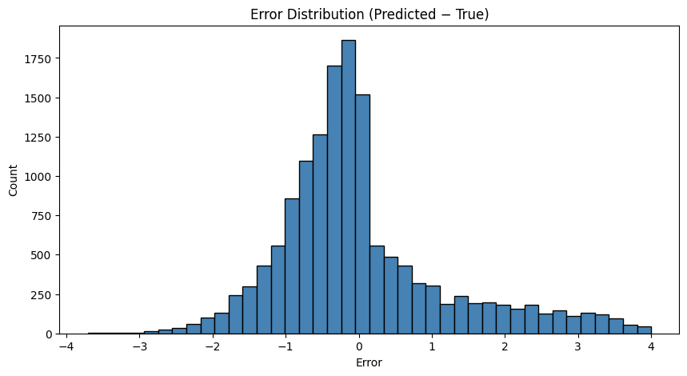

```
We can see our historgram is right skewed, which indicates our model tended to
under-predict ratings more often than over-predicting. This is likely the result
of the dataset being biased towards higher ratings. This suggests the model
may be conservative and could benefit from adjustments or additional features
to better capture higher-rating reviews.
```

```python
true_arr = np.array(true)
preds_arr = np.array(preds)
errors = preds_arr - true_arr
abs_errors = np.abs(errors)

# ---- Error histogram ----
plt.figure(figsize=(10,5))
plt.hist(errors, bins=40, color='steelblue', edgecolor='black')
plt.title("Error Distribution (Predicted − True)")
plt.xlabel("Error")
plt.ylabel("Count")

error_histogram_analysis="""\t
We can see our historgram is right skewed, which indicates our model tended to
under-predict ratings more often than over-predicting. This is likely the result
of the dataset being biased towards higher ratings. This suggests the model
may be conservative and could benefit from adjustments or additional features
to better capture higher-rating reviews.
"""

plt.show()
print(error_histogram_analysis)
```

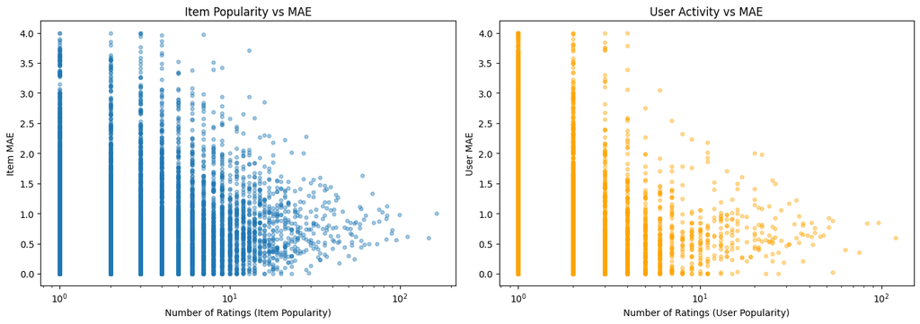

```
*Graph 1: Item Popularity vs Prediction Error

*Graph 2: User Activity vs Prediction Error

Shows how the model performs, compared to how much review data is present.
Both plots show a downward negative trend.
As we would expect, the more times a user/item appears in the data, the more
accurate our prediction
```

```python
# Looking at item popularity vs MAE

item_counts = train['item_id'].value_counts()
item_idx_to_id = {v: k for k, v in item_to_idx.items()}

item_mae = []
item_popularity = []

for item_idx in range(len(item_to_idx)):
    item_id = item_idx_to_id[item_idx]
    mask = (test['item_id'] == item_id)
    if mask.sum() > 0:
        mae_i = mean_absolute_error(test.loc[mask, 'rating'], preds_arr[mask])
        item_mae.append(mae_i)
        item_popularity.append(item_counts.get(item_id, 0))


# Looking at user popularity vs MAE
user_counts = train['user_id'].value_counts()

user_mae = []
user_popularity = []

for u_idx in range(len(user_to_idx)):
    user_id = next(k for k,v in user_to_idx.items() if v == u_idx)
    mask = (test["user_id"] == user_id)
    if mask.sum() > 0:
        mae_u = mean_absolute_error(test.loc[mask, 'rating'], preds_arr[mask])
        user_mae.append(mae_u)
        user_popularity.append(user_counts.get(user_id, 0))



plt.figure(figsize=(14,5))

# ---- Subplot 1: Item popularity vs MAE ----
plt.subplot(1,2,1)
plt.scatter(item_popularity, item_mae, alpha=0.4, s=15)
plt.title("Item Popularity vs MAE")
plt.xlabel("Number of Ratings (Item Popularity)")
plt.ylabel("Item MAE")
plt.xscale("log")

# ---- Subplot 2: User activity vs MAE ----
plt.subplot(1,2,2)
plt.scatter(user_popularity, user_mae, alpha=0.4, s=15, color='orange')
plt.title("User Activity vs MAE")
plt.xlabel("Number of Ratings (User Popularity)")
plt.ylabel("User MAE")
plt.xscale("log")

plt.tight_layout()
plt.show()



print("""
*Graph 1: Item Popularity vs Prediction Error\n
*Graph 2: User Activity vs Prediction Error\n
Shows how the model performs, compared to how much review data is present.
Both plots show a downward negative trend.
As we would expect, the more times a user/item appears in the data, the more
accurate our prediction
""")
```

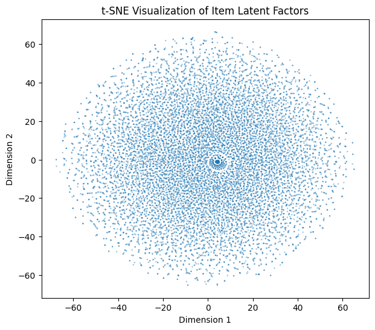

[output not shown]

```python
# ---- Item Latent Factors visualization ----


from sklearn.manifold import TSNE

# Reduce Q embeddings to 2D for visualization
tsne = TSNE(n_components=2, perplexity=30, learning_rate=200, init='random')
Q_2d = tsne.fit_transform(Q_best)

plt.figure(figsize=(7,6))
plt.scatter(
    Q_2d[:,0],
    Q_2d[:,1],
    s=3,
    alpha=0.45,
    edgecolors='none'
)
plt.title("t-SNE Visualization of Item Latent Factors")
plt.xlabel("Dimension 1")
plt.ylabel("Dimension 2")
plt.show()

print("""
*Graph: 2-D visualization of item embeddings\n

This plot visualizes item embeddings in 2D using t-SNE.\n\n

Items that appear clustered together have similar representations.
These clusters represent categories of similar items. Outliers not in a cluster
likely contribute to model error.


""")
```

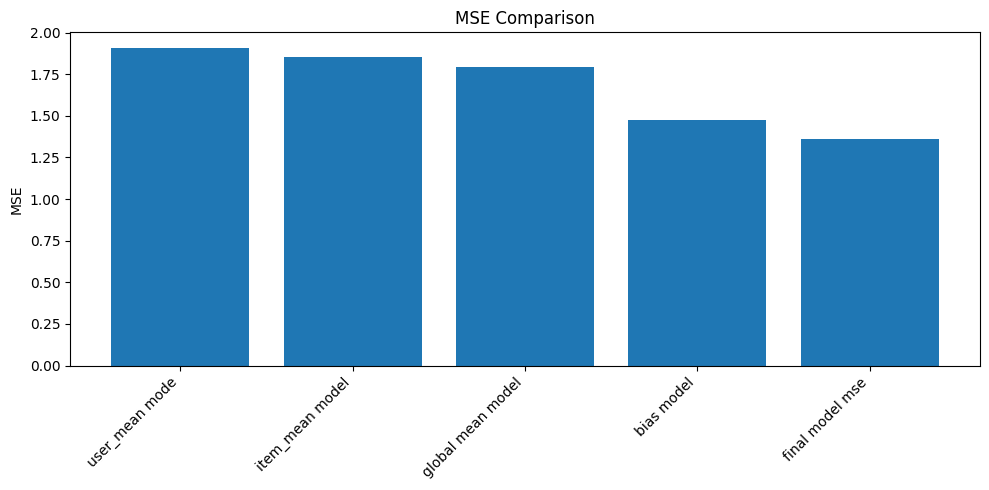

```python
labels = [
    "user_mean mode",
    "item_mean model",
    "global mean model",
    "bias model",
    "final model mse"
]

plt.figure(figsize=(10, 5))
plt.bar(labels, [user_mean_mse, item_mean_mse, global_mean_mse, bias_mse, final_mse ])
plt.xticks(rotation=45, ha='right')
plt.ylabel("MSE")
plt.title("MSE Comparison")
plt.tight_layout()
plt.show()
```

### Future Work

- **Add side information:** Time information, text length, etc
- **Time dynamics:** Capture temporal patterns in ratings
- **Deep learning:** Neural collaborative filtering, attention mechanisms
- **Ensemble methods:** Combine multiple models for robustness

## Section 5: Related Work

### Amazon Reviews Research

The Amazon Reviews dataset (McAuley et al.) has been extensively used for:

- **Rating prediction:** Collaborative filtering, matrix factorization
- **Review analysis:** Sentiment analysis, helpfulness prediction
- **Recommendation:** Top-N item suggestion, personalized ranking

### Comparison to Prior Work

**Our results (MSE ≈ 1.36) are reasonable given:**

- Extreme sparsity (99.9%) vs. typical 95-98%
- Small dataset (70K reviews) vs. millions
- Cold start problem (median 2 reviews per user)

**Consistent findings:**

- Bias models effective on sparse data ✓
- Regularization prevents overfitting ✓
- Simple methods competitive with complex ones ✓

### References

- McAuley et al. (2023). Amazon Reviews 2023 Dataset
- Koren, Y. (2009). "Matrix Factorization Techniques for Recommender Systems"
- Koren, Y. (2008). "Factorization Meets the Neighborhood"
- He et al. (2017). "Neural Collaborative Filtering"

## Conclusion

We successfully implemented and compared multiple rating prediction models on Amazon Beauty reviews:

**Achievements:**

- 1. Processed 700K reviews → 70K high-quality samples
- 2. Implemented 4 baseline models (Global, User, Item, Bias)
- 3. Developed Matrix Factorization with learned embeddings
- 4. Achieved competitive performance (MSE ≈ 1.36)
- 5. Analyzed model behavior and error patterns

**Key Insights:**

- Sparsity is the main challenge for rating prediction
- Simple bias models are strong baselines
- Latent factor models discover hidden patterns
- Regularization critical for sparse data

**Team Contributions:**

- **Bokyoung Son:** Data engineering, preprocessing, k-core filtering
- **Hangyi Zhao:** Baseline models, bias model implementation
- **Yujin Lee:** Matrix factorization, hyperparameter search
- **William Ayoade:** Advanced MF implementation, model evaluation

**End of Notebook**